# Session 2

Basic Hui-Walter models

Matt Denwood

2021-06-28

## Hui-Walter Model

- A particular model formulation that was originally designed for evaluating diagnostic tests in the absence of a gold standard
- Not necessarily (or originally) Bayesian but often implemented using Bayesian MCMC
- But evaluating an imperfect test against another imperfect test is a bit like pulling a rabbit out of a hat
  - If we don’t know the true disease status, how can we estimate sensitivity or specificity for either test?

## The multinomial distribution

Binomial (always with two possible outcomes):

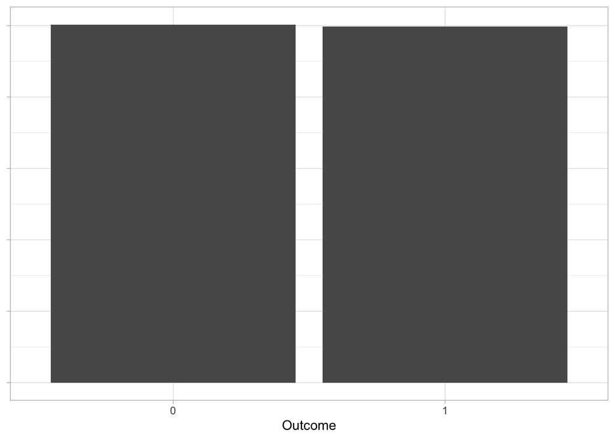

Multinomial with two possible outcomes:

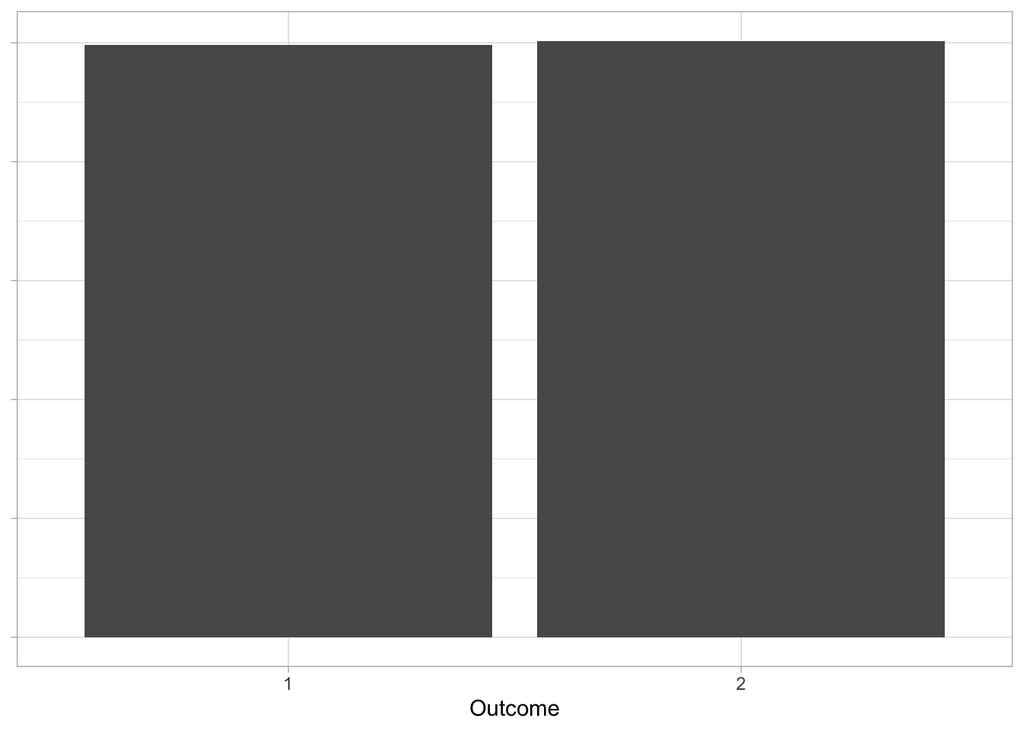

Multinomial with four possible outcomes:

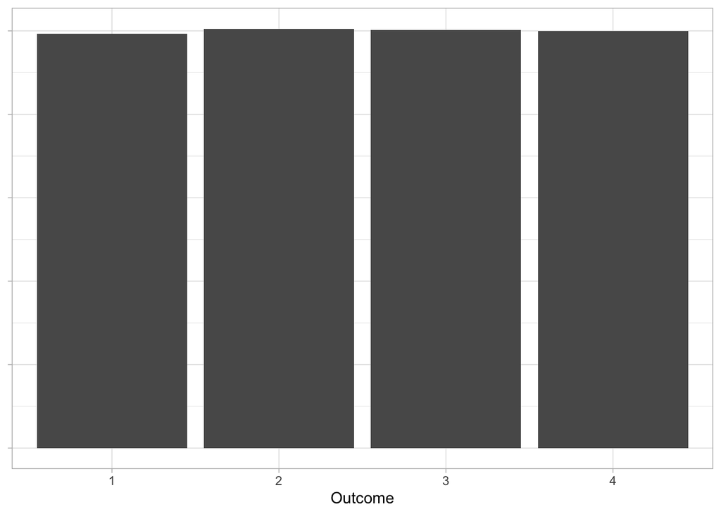

## Model Specification

```
model{
  Tally ~ dmulti(prob, N)

  # Test1- Test2-
    prob[1] <- (prev * ((1-se[1])*(1-se[2]))) + ((1-prev) * ((sp[1])*(sp[2])))

  # Test1+ Test2-
    prob[2] <- (prev * ((se[1])*(1-se[2]))) + ((1-prev) * ((1-sp[1])*(sp[2])))

  # Test1- Test2+
    prob[3] <- (prev * ((1-se[1])*(se[2]))) + ((1-prev) * ((sp[1])*(1-sp[2])))
```

```
  # Test1+ Test2+
    prob[4] <- (prev * ((se[1])*(se[2]))) + ((1-prev) * ((1-sp[1])*(1-sp[2])))

  prev ~ dbeta(1, 1)
  se[1] ~ dbeta(1, 1)
  sp[1] ~ dbeta(1, 1)
  se[2] ~ dbeta(1, 1)
  sp[2] ~ dbeta(1, 1)

  #data# Tally, N
  #monitor# prev, prob, se, sp, deviance
  #inits# prev, se, sp
}
```

```r
twoXtwo <- matrix(c(48, 12, 4, 36), ncol=2, nrow=2)
twoXtwo
##      [,1] [,2]
## [1,]   48    4
## [2,]   12   36
```

```r
library('runjags')

Tally <- as.numeric(twoXtwo)
N <- sum(Tally)

prev <- list(chain1=0.05, chain2=0.95)
se <- list(chain1=c(0.01,0.99), chain2=c(0.99,0.01))
sp <- list(chain1=c(0.01,0.99), chain2=c(0.99,0.01))

results <- run.jags('basic_hw.txt', n.chains=2)
```

[Remember to check convergence and effective sample size!]

```r
results
```

|  | Lower95 | Median | Upper95 | SSeff | psrf |
| --- | --- | --- | --- | --- | --- |
| prev | 0.328 | 0.499 | 0.668 | 4250 | 2.288 |
| prob[1] | 0.367 | 0.462 | 0.558 | 13858 | 1.000 |
| prob[2] | 0.072 | 0.132 | 0.202 | 14200 | 1.000 |
| prob[3] | 0.018 | 0.055 | 0.104 | 9602 | 1.000 |
| prob[4] | 0.255 | 0.343 | 0.438 | 13555 | 1.000 |
| se[1] | 0.028 | 0.570 | 1.000 | 4564 | 15.155 |
| se[2] | 0.000 | 0.385 | 0.965 | 4585 | 13.619 |
| sp[1] | 0.000 | 0.461 | 0.970 | 4527 | 15.261 |
| sp[2] | 0.036 | 0.581 | 1.000 | 4593 | 13.641 |
| deviance | 12.304 | 15.134 | 21.447 | 8838 | 1.000 |

- Does anybody spot a problem?

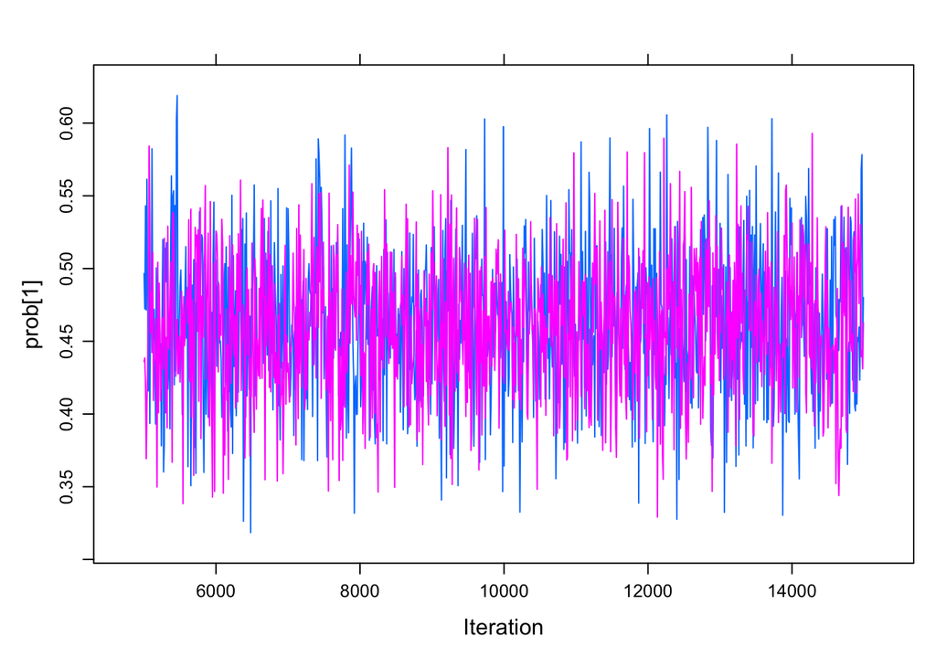

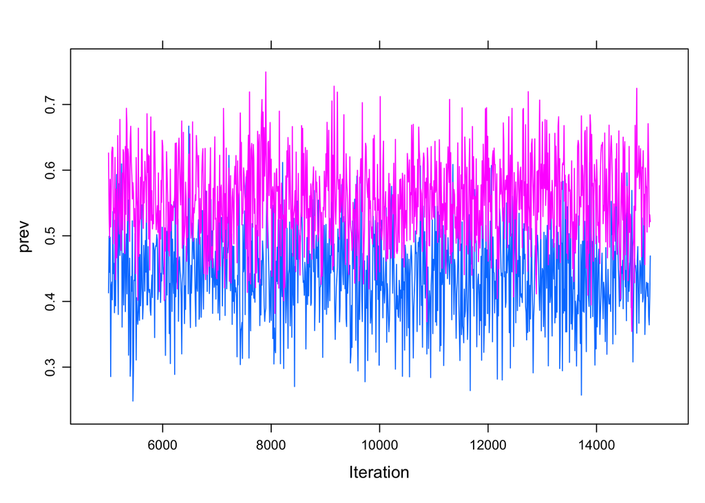

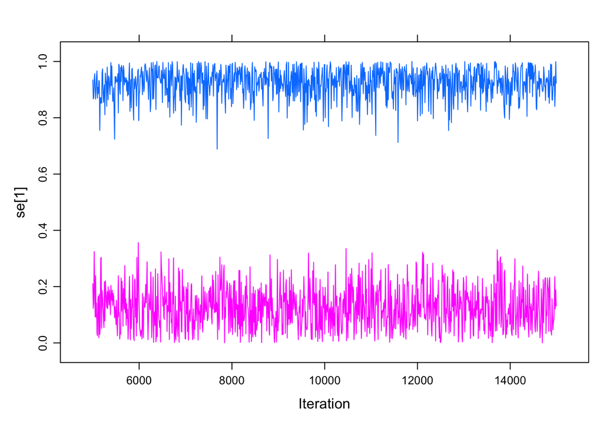

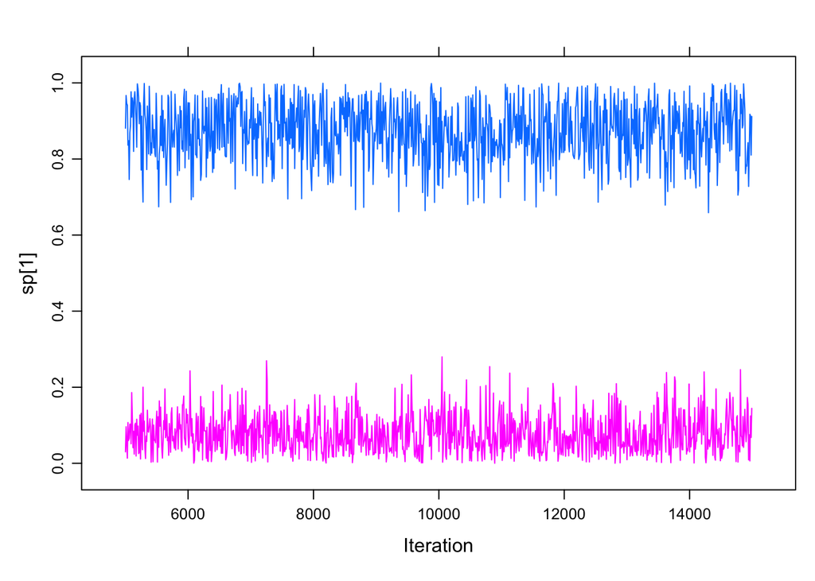

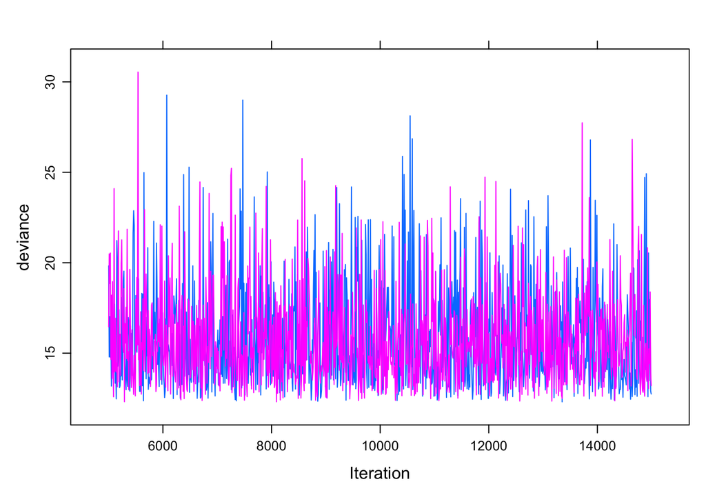

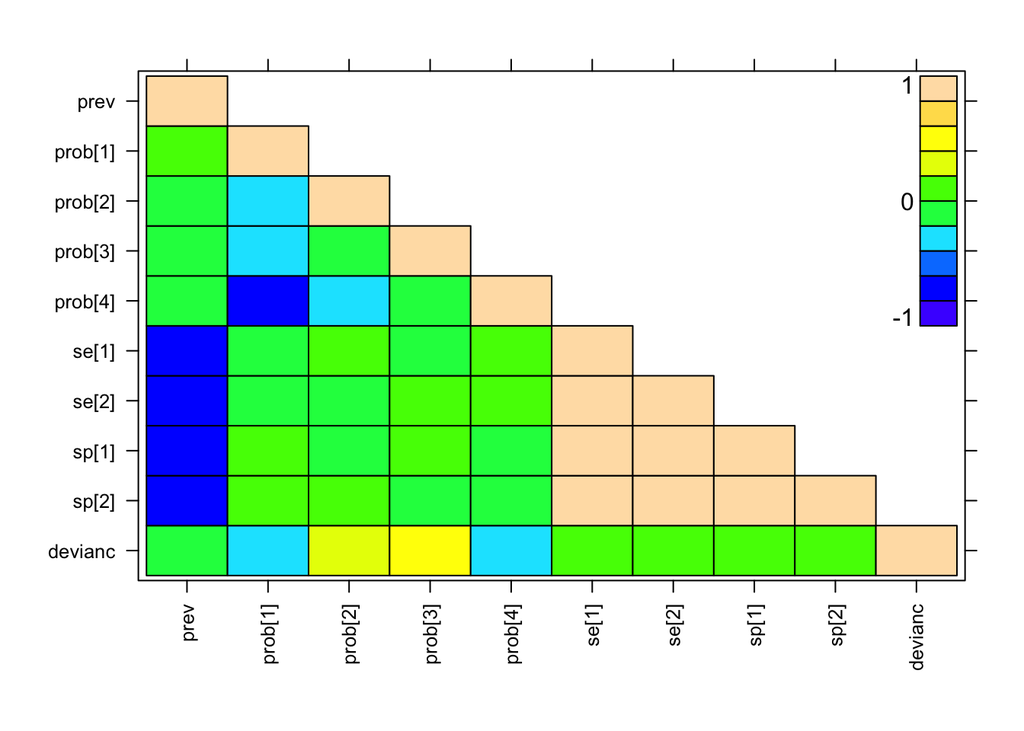

## Label Switching

How to interpret a test with Se=0% and Sp=0%?

- The test is perfect - we are just holding it upside down…

We can force se+sp >= 1:

```r
  se[1] ~ dbeta(1, 1)
  sp[1] ~ dbeta(1, 1)T(1-se[1], )
```

Or:

```r
  se[1] ~ dbeta(1, 1)T(1-sp[1], )
  sp[1] ~ dbeta(1, 1)
```

This allows the test to be useless, but not worse than useless.

Alternatively we can have the weakly informative priors:

```r
  se[1] ~ dbeta(2, 1)
  sp[1] ~ dbeta(2, 1)
```

To give the model some information that we expect the test characteristics to be closer to 100% than 0%.

Or we can use stronger priors for one or both tests.

## Priors

A quick way to see the distribution of a prior:

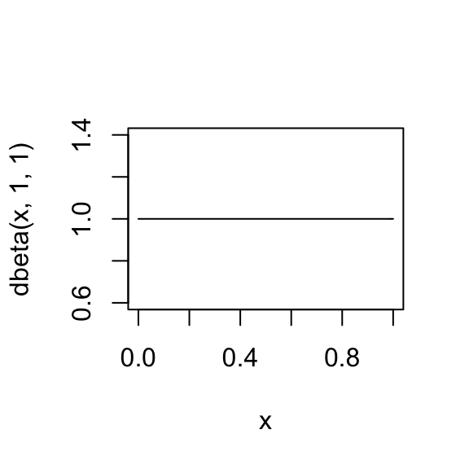

```r
curve(dbeta(x, 1, 1), from=0, to=1)
```

```r
qbeta(c(0.025,0.975), shape1=1, shape2=1)
## [1] 0.025 0.975
```

This was minimally informative, but how does that compare to a weakly informative prior for e.g. sensitivity?

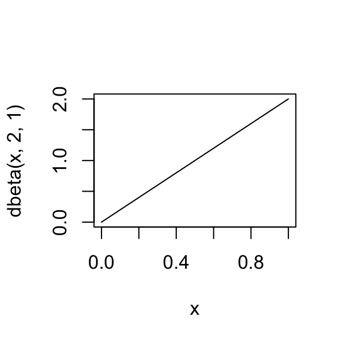

```r
curve(dbeta(x, 2, 1), from=0, to=1)
```

```r
qbeta(c(0.025,0.975), shape1=2, shape2=1)
## [1] 0.1581139 0.9874209
```

```r
qbeta(c(0.025,0.975), shape1=2, shape2=1)
## [1] 0.1581139 0.9874209
```

Or more accurately:

```r
library("TeachingDemos")
hpd(qbeta, shape1=2, shape2=1)
## [1] 0.2236068 1.0000000
```

Credible vs confidence intervals:

- For MCMC these are usually calculated using highest posterior density (HPD) intervals
- Therefore there is a difference between:
  - `qbeta(c(0.025,0.975), ...)`
  - `hpd(qbeta, ...)`
- Technically HPD intervals are credible intervals…

What about a more informative prior?

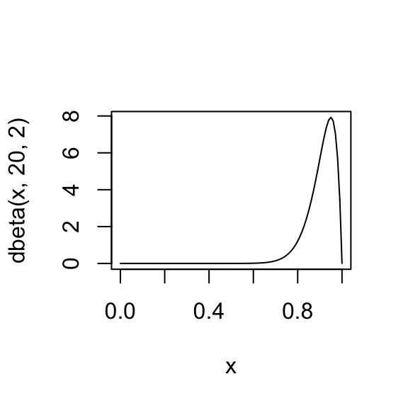

```r
curve(dbeta(x, 20, 2), from=0, to=1)
```

```r
qbeta(c(0.025,0.975), shape1=20, shape2=2)
## [1] 0.7618401 0.9882507
hpd(qbeta, shape1=20, shape2=2)
## [1] 0.7919691 0.9973994
```

## Choosing a prior

What we want is e.g. Beta(20,1)

But typically we have median and 95% confidence intervals from a paper, e.g.:

“The median (95% CI) estimates of the sensitivity and specificity of the shiny new test were 94% (92-96%) and 99% (97-100%) respectively”

How can we generate a Beta( , ) prior from this?

## The PriorGen package

“The median (95% CI) estimates of the sensitivity and specificity of the shiny new test were 94% (92-96%) and 99% (97-100%)”

```r
library("PriorGen")
## Loading required package: rootSolve
findbeta(themedian = 0.94, percentile.value = 0.92)
## [1] "The desired Beta distribution that satisfies the specified conditions is: Beta( 429.95 27.76 )"
## [1] "Here is a plot of the specified distribution."
## [1] "Descriptive statistics for this distribution are:"
##    Min. 1st Qu.  Median    Mean 3rd Qu.    Max.
##  0.8906  0.9322  0.9401  0.9395  0.9474  0.9721
## [1] "Verification: The percentile value 0.92 corresponds to the 0.05 th percentile"
hpd(qbeta, shape1=429.95, shape2=27.76)
## [1] 0.917172 0.960435
```

Note: `themedian` could also be `themean`

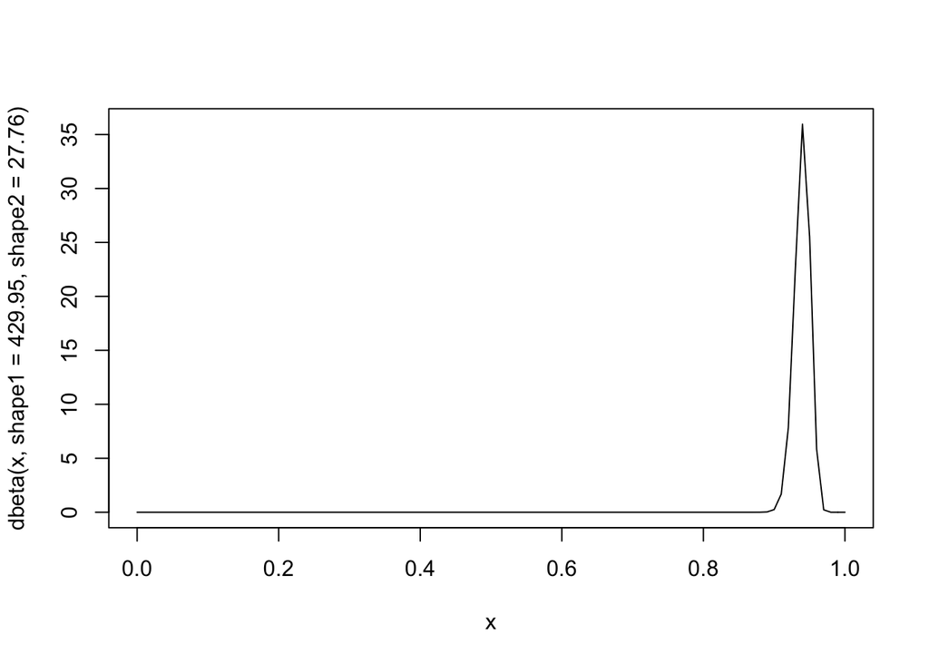

```r
curve(dbeta(x, shape1=429.95, shape2=27.76))
```

## Initial values

Part of the problem before was also that we were specifying extreme initial values:

```r
se <- list(chain1=c(0.01,0.99), chain2=c(0.99,0.01))
sp <- list(chain1=c(0.01,0.99), chain2=c(0.99,0.01))
```

Let’s change these to:

```r
se <- list(chain1=c(0.5,0.99), chain2=c(0.99,0.5))
sp <- list(chain1=c(0.5,0.99), chain2=c(0.99,0.5))
```

## Analysing simulated data

This is useful to check that we can recover parameter values!

```r
# Set a random seed so that the data are reproducible:
set.seed(2021-06-28)

sensitivity <- c(0.9, 0.6)
specificity <- c(0.95, 0.9)
N <- 1000
prevalence <- 0.5

data <- tibble(Status = rbinom(N, 1, prevalence)) %>%
  mutate(Test1 = rbinom(N, 1, sensitivity[1]*Status + (1-specificity[1])*(1-Status))) %>%
  mutate(Test2 = rbinom(N, 1, sensitivity[2]*Status + (1-specificity[2])*(1-Status)))

twoXtwo <- with(data, table(Test1, Test2))
Tally <- as.numeric(twoXtwo)
```

We know that e.g. the first test has Sensitivity of 90% and Specificity of 95% - so the model *should* be able to tell us that…

# Practical Session 2

## Points to consider

1. What is the typical autocorrelation (and therefore effective sample size) of Hui-Walter models compared to the simpler models we were running earlier? Is there any practical consequence of this?
2. How does changing the prior distributions for the se and sp of one test affect the inference for the other test parameters?

## Exercise 1

Simulate some data using the code given above (under “Analysing simulated data”), and run it using the following model with truncated Beta(1,1) priors for sensitivity and specificity of both tests:

```
model{
  Tally ~ dmulti(prob, N)

  # Test1- Test2-
    prob[1] <- (prev * ((1-se[1])*(1-se[2]))) + ((1-prev) * ((sp[1])*(sp[2])))

  # Test1+ Test2-
    prob[2] <- (prev * ((se[1])*(1-se[2]))) + ((1-prev) * ((1-sp[1])*(sp[2])))

  # Test1- Test2+
    prob[3] <- (prev * ((1-se[1])*(se[2]))) + ((1-prev) * ((sp[1])*(1-sp[2])))

  # Test1+ Test2+
    prob[4] <- (prev * ((se[1])*(se[2]))) + ((1-prev) * ((1-sp[1])*(1-sp[2])))

  prev ~ dbeta(1, 1)
  se[1] ~ dbeta(1, 1)T(1-sp[1], )
  sp[1] ~ dbeta(1, 1)
  se[2] ~ dbeta(1, 1)T(1-sp[2], )
  sp[2] ~ dbeta(1, 1)

  #data# Tally, N
  #monitor# prev, prob, se, sp, deviance
  #inits# prev, se, sp
}
```

What are the results?

### Solution 1

```r
prev <- list(chain1=0.05, chain2=0.95)
se <- list(chain1=c(0.5,0.99), chain2=c(0.99,0.5))
sp <- list(chain1=c(0.5,0.99), chain2=c(0.99,0.5))

results_tr_1000 <- run.jags('hw_truncated.txt', n.chains=2, sample=10000)

# Note: this is only commented out to save space in the exercise file!
# plot(results_tr_1000)
# check convergence and effective sample size, and then interpret results:
results_tr_1000
##
## JAGS model summary statistics from 20000 samples (chains = 2; adapt+burnin = 5000):
##
##           Lower95   Median Upper95     Mean        SD Mode       MCerr MC%ofSD
## prev      0.24935  0.41372  0.5901  0.41993  0.093566   --   0.0063514     6.8
## prob[1]   0.39129  0.42301 0.45284  0.42307  0.015686   --  0.00012468     0.8
## prob[2]    0.1863  0.21128 0.23631   0.2115  0.012947   --  0.00010118     0.8
## prob[3]  0.071623 0.088627 0.10675 0.088923 0.0090027   -- 0.000074665     0.8
## prob[4]   0.24818  0.27631  0.3038  0.27651  0.014234   --  0.00012076     0.8
## se[1]     0.75914  0.86585 0.99948  0.86959  0.072446   --   0.0030791     4.3
## se[2]     0.56163  0.73718  0.9829  0.75074   0.12475   --   0.0079031     6.3
## sp[1]     0.65965  0.77867 0.98522  0.79526  0.095061   --   0.0063132     6.6
## sp[2]     0.82518  0.89678  0.9998   0.9008   0.05144   --   0.0021431     4.2
## deviance   20.103   22.529  28.127   23.177    2.4851   --    0.024965       1
##
##          SSeff      AC.10    psrf
## prev       217    0.80242  1.0108
## prob[1]  15829  0.0026764 0.99995
## prob[2]  16374  0.0002449       1
## prob[3]  14538   0.010654       1
## prob[4]  13894 -0.0022874  1.0002
## se[1]      554    0.56703  1.0047
## se[2]      249    0.76681  1.0043
## sp[1]      227    0.77754  1.0061
## sp[2]      576    0.55889  1.0059
## deviance  9909   0.017552  1.0003
##
## Total time taken: 1.9 seconds
```

Note that model does converge, but the effective sample size is NOT high enough with 10000 samples - we need to run for longer to get reliable results:

```r
results_tr_1000 <- run.jags('hw_truncated.txt', n.chains=2, sample=75000)

# Note: this is only commented out to save space in the exercise file!
# plot(results_tr_1000)
# check convergence and effective sample size, and then interpret results:
results_tr_1000
##
## JAGS model summary statistics from 150000 samples (chains = 2; adapt+burnin = 5000):
##
##           Lower95   Median Upper95     Mean        SD Mode       MCerr MC%ofSD
## prev      0.25646   0.4149 0.59214  0.41946  0.091155   --   0.0023603     2.6
## prob[1]   0.39133  0.42262 0.45242  0.42261  0.015622   --  0.00011387     0.7
## prob[2]   0.18639   0.2114 0.23689   0.2116  0.012865   -- 0.000090971     0.7
## prob[3]  0.071818 0.088607 0.10643 0.088916 0.0089317   -- 0.000065062     0.7
## prob[4]   0.24925  0.27666  0.3044  0.27687  0.014223   --  0.00010057     0.7
## se[1]     0.75987  0.86544  0.9998  0.86925  0.071512   --   0.0011628     1.6
## se[2]     0.55879  0.73806 0.97839  0.75232   0.12459   --   0.0031238     2.5
## sp[1]     0.65331  0.77735 0.97743   0.7937  0.094289   --   0.0024201     2.6
## sp[2]     0.82559  0.89692 0.99973  0.90092   0.05109   --  0.00084354     1.7
## deviance   20.116   22.527  27.938   23.149     2.436   --    0.017047     0.7
##
##          SSeff      AC.10    psrf
## prev      1492    0.79674  1.0003
## prob[1]  18821  0.0064088  1.0001
## prob[2]  20000  0.0037304       1
## prob[3]  18846  0.0015334 0.99999
## prob[4]  20000 0.00063144       1
## se[1]     3782     0.5585  1.0008
## se[2]     1591    0.77295  1.0011
## sp[1]     1518     0.7807  1.0011
## sp[2]     3668    0.55971  1.0007
## deviance 20420  0.0012241  1.0001
##
## Total time taken: 6.2 seconds
```

Now we can see that the 95% confidence intervals for prev, se and sp are all quite wide, but at least they do contain the simulation values!

## Exercise 2

- Find beta distribution priors for:
  - Sensitivity: mean estimate = 0.9 (95% CI: 0.85 - 0.95)
  - Specificity: mean estimate = 0.95 (95%CI: 0.92-0.97)
- Look at these distributions using curve and hpd
- Modify your model from exercise 1 using these priors for test 1 (leave the priors for test 2 unchanged)
  - Make sure to name your new model something different, so that you can easily run it using either set of priors for test 1!
- How does this affect the inference for test 2?

### Solution 2

Parameters for Sensitivity: mean estimate = 0.9 (95% CI: 0.85 - 0.95):

[Note: this is `themean` rather than `themedian`!]

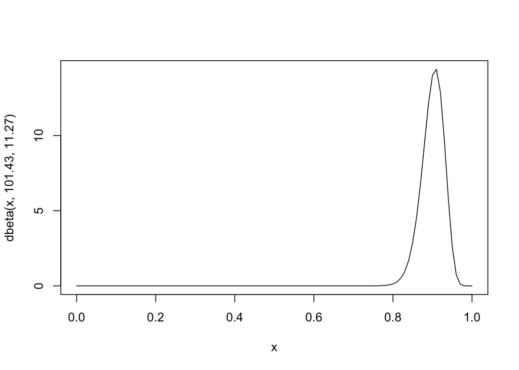

```r
PriorGen::findbeta(themean=0.9, percentile.value = 0.85)
## [1] "The desired Beta distribution that satisfies the specified conditions is: Beta( 101.43 11.27 )"
## [1] "Here is a plot of the specified distribution."
## [1] "Descriptive statistics for this distribution are:"
##    Min. 1st Qu.  Median    Mean 3rd Qu.    Max.
##  0.7660  0.8824  0.9021  0.8999  0.9199  0.9724
## [1] "Verification: The percentile value 0.85 corresponds to the 0.05 th percentile"
hpd(qbeta, shape1=101.43, shape2=11.27)
## [1] 0.8439990 0.9518919
curve(dbeta(x, 101.43, 11.27), from=0, to=1)
```

Parameters for Specificity: mean estimate = 0.95 (95%CI: 0.92-0.97):

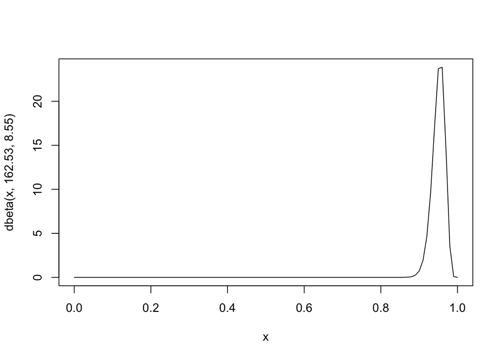

```r
PriorGen::findbeta(themean=0.95, percentile.value = 0.92)
## [1] "The desired Beta distribution that satisfies the specified conditions is: Beta( 162.53 8.55 )"
## [1] "Here is a plot of the specified distribution."
## [1] "Descriptive statistics for this distribution are:"
##    Min. 1st Qu.  Median    Mean 3rd Qu.    Max.
##  0.8647  0.9404  0.9519  0.9503  0.9620  0.9908
## [1] "Verification: The percentile value 0.92 corresponds to the 0.05 th percentile"
hpd(qbeta, shape1=162.53, shape2=8.55)
## [1] 0.9169589 0.9799619
curve(dbeta(x, 162.53, 8.55), from=0, to=1)
```

Here is the updated model using the new prior values:

```
model{
  Tally ~ dmulti(prob, N)

  # Test1- Test2-
    prob[1] <- (prev * ((1-se[1])*(1-se[2]))) + ((1-prev) * ((sp[1])*(sp[2])))

  # Test1+ Test2-
    prob[2] <- (prev * ((se[1])*(1-se[2]))) + ((1-prev) * ((1-sp[1])*(sp[2])))

  # Test1- Test2+
    prob[3] <- (prev * ((1-se[1])*(se[2]))) + ((1-prev) * ((sp[1])*(1-sp[2])))

  # Test1+ Test2+
    prob[4] <- (prev * ((se[1])*(se[2]))) + ((1-prev) * ((1-sp[1])*(1-sp[2])))

  prev ~ dbeta(1, 1)
  se[1] ~ dbeta(101.43, 11.27)T(1-sp[1], )
  sp[1] ~ dbeta(162.53, 8.55)
  se[2] ~ dbeta(1, 1)T(1-sp[2], )
  sp[2] ~ dbeta(1, 1)

  #data# Tally, N
  #monitor# prev, prob, se, sp, deviance
  #inits# prev, se, sp
}
```

```r
results_si_1000 <- run.jags('hw_stronginf.txt', n.chains=2)

# Note: this is only commented out to save space in the exercise file!
# plot(results_si_1000)
# check convergence and effective sample size, and then interpret results:
results_si_1000
##
## JAGS model summary statistics from 20000 samples (chains = 2; adapt+burnin = 5000):
##
##          Lower95   Median Upper95     Mean       SD Mode       MCerr MC%ofSD
## prev     0.46438   0.5157 0.57108  0.51673  0.02759   --  0.00050216     1.8
## prob[1]  0.39356  0.42372 0.45383  0.42378 0.015465   --  0.00013204     0.9
## prob[2]  0.18508  0.20999   0.235  0.21017 0.012732   --  0.00012268       1
## prob[3]  0.07089 0.087687 0.10619 0.087984 0.009043   -- 0.000085882     0.9
## prob[4]     0.25  0.27802 0.30511  0.27806 0.014021   --  0.00012496     0.9
## se[1]    0.84125   0.9004 0.95136  0.89812 0.028598   --   0.0005644       2
## se[2]     0.5431  0.59319 0.64244   0.5935 0.025101   --  0.00028133     1.1
## sp[1]    0.91572  0.95102  0.9798   0.9493 0.016813   --  0.00022111     1.3
## sp[2]     0.8256  0.87599 0.93084  0.87775 0.026648   --  0.00047421     1.8
## deviance  20.104   22.448  27.946   23.085    2.447   --    0.023791       1
##
##          SSeff      AC.10    psrf
## prev      3019   0.072196   1.002
## prob[1]  13718 -0.0042517  1.0002
## prob[2]  10770   0.016437 0.99997
## prob[3]  11087  0.0081593       1
## prob[4]  12590  0.0094429  1.0003
## se[1]     2567   0.098028  1.0006
## se[2]     7961   0.020262 0.99999
## sp[1]     5782   0.010922  1.0006
## sp[2]     3158   0.079423  1.0013
## deviance 10579 0.00087204  1.0002
##
## Total time taken: 1.6 seconds
```

Note that the 95% confidence intervals are much narrower now, including for test 2!!! The effective sample size is also much higher because the model is more identifiable (i.e. better behaved).

## Exercise 3

Now adjust the sample size so that you have N=100, re-simulate the data, and re-run the models with both sets of priors.

- What do you notice about the results compared to N=1000?

Also change the prevalence from 50% to 10% or 90%

- How does this affect your ability to estimate the sensitivity and specificity of test 2 (using strong priors for test 1)?

### Solution 3

We can change the sample size like so:

```r
# Set a random seed so that the data are reproducible:
set.seed(2021-06-28)

se <- c(0.9, 0.6)
sp <- c(0.95, 0.9)
N <- 100
prevalence <- 0.5

data <- tibble(Status = rbinom(N, 1, prevalence)) %>%
  mutate(Test1 = rbinom(N, 1, se[1]*Status + (1-sp[1])*(1-Status))) %>%
  mutate(Test2 = rbinom(N, 1, se[2]*Status + (1-sp[2])*(1-Status)))

twoXtwo <- with(data, table(Test1, Test2))
Tally <- as.numeric(twoXtwo)

results_si_100 <- run.jags('hw_stronginf.txt', n.chains=2)
results_tr_100 <- run.jags('hw_truncated.txt', n.chains=2)

# Remember to check convergence!
# plot(results_si_100)
# plot(results_tr_100)

# Comparison to larger dataset:
results_si_100
##
## JAGS model summary statistics from 20000 samples (chains = 2; adapt+burnin = 5000):
##
##           Lower95  Median Upper95    Mean       SD Mode      MCerr MC%ofSD
## prev       0.3728 0.49467 0.61445 0.49569 0.062289   -- 0.00063836       1
## prob[1]   0.32695 0.42083 0.51876 0.42136 0.049086   -- 0.00042964     0.9
## prob[2]   0.15838 0.23845 0.32186 0.24032 0.042245   --  0.0003951     0.9
## prob[3]  0.051924 0.10562 0.16834 0.10805 0.030492   -- 0.00030267       1
## prob[4]   0.15273 0.22865 0.31156 0.23027 0.040769   -- 0.00036458     0.9
## se[1]     0.84092   0.901 0.95099 0.89845 0.028608   -- 0.00029942       1
## se[2]     0.36149 0.50804 0.65665 0.50854 0.075522   -- 0.00070074     0.9
## sp[1]     0.91543 0.95095 0.97932 0.94934  0.01694   -- 0.00017439       1
## sp[2]     0.70774 0.83221 0.94923 0.82933  0.06243   -- 0.00064111       1
## deviance    13.32  15.659  21.035  16.291     2.41   --   0.025065       1
##
##          SSeff      AC.10   psrf
## prev      9521  0.0036968 1.0002
## prob[1]  13053  0.0032108 1.0002
## prob[2]  11432  0.0074274 1.0001
## prob[3]  10149  0.0041581 1.0003
## prob[4]  12505  -0.009899 1.0002
## se[1]     9129 -0.0026525 1.0001
## se[2]    11615  0.0013375      1
## sp[1]     9437  0.0039154 1.0001
## sp[2]     9482  0.0076993 1.0001
## deviance  9245 -0.0063151 1.0003
##
## Total time taken: 1.5 seconds
results_tr_100
##
## JAGS model summary statistics from 20000 samples (chains = 2; adapt+burnin = 5000):
##
##           Lower95  Median Upper95    Mean       SD Mode      MCerr MC%ofSD
## prev      0.10668 0.38316   0.687 0.39437  0.15363   --  0.0041382     2.7
## prob[1]   0.31431 0.40512 0.50362 0.40558 0.048643   -- 0.00044904     0.9
## prob[2]   0.17356 0.25661 0.34144 0.25773 0.043381   -- 0.00042202       1
## prob[3]  0.060674  0.1189 0.18889 0.12153 0.033098   -- 0.00036268     1.1
## prob[4]   0.13646 0.21344 0.29482 0.21516 0.040916   --  0.0003976       1
## se[1]     0.57023 0.79104 0.99995 0.78591  0.12457   --  0.0022353     1.8
## se[2]     0.40736 0.64212 0.99836 0.66009   0.1681   --  0.0039884     2.4
## sp[1]     0.54479 0.72202 0.98277 0.73715  0.11994   --  0.0028317     2.4
## sp[2]     0.71718 0.85548 0.99996 0.85411  0.08072   --   0.001296     1.6
## deviance   13.349  16.268  23.038  17.028   2.9208   --   0.040089     1.4
##
##          SSeff      AC.10    psrf
## prev      1378    0.25679  1.0004
## prob[1]  11735 -0.0033511 0.99996
## prob[2]  10566  0.0076981  1.0001
## prob[3]   8329   0.012826  1.0001
## prob[4]  10590   0.010937  1.0004
## se[1]     3105   0.067733  1.0003
## se[2]     1776     0.1932  1.0002
## sp[1]     1794    0.18247  1.0001
## sp[2]     3879   0.056161       1
## deviance  5308   0.015854  1.0007
##
## Total time taken: 1.8 seconds
results_si_1000
##
## JAGS model summary statistics from 20000 samples (chains = 2; adapt+burnin = 5000):
##
##          Lower95   Median Upper95     Mean       SD Mode       MCerr MC%ofSD
## prev     0.46438   0.5157 0.57108  0.51673  0.02759   --  0.00050216     1.8
## prob[1]  0.39356  0.42372 0.45383  0.42378 0.015465   --  0.00013204     0.9
## prob[2]  0.18508  0.20999   0.235  0.21017 0.012732   --  0.00012268       1
## prob[3]  0.07089 0.087687 0.10619 0.087984 0.009043   -- 0.000085882     0.9
## prob[4]     0.25  0.27802 0.30511  0.27806 0.014021   --  0.00012496     0.9
## se[1]    0.84125   0.9004 0.95136  0.89812 0.028598   --   0.0005644       2
## se[2]     0.5431  0.59319 0.64244   0.5935 0.025101   --  0.00028133     1.1
## sp[1]    0.91572  0.95102  0.9798   0.9493 0.016813   --  0.00022111     1.3
## sp[2]     0.8256  0.87599 0.93084  0.87775 0.026648   --  0.00047421     1.8
## deviance  20.104   22.448  27.946   23.085    2.447   --    0.023791       1
##
##          SSeff      AC.10    psrf
## prev      3019   0.072196   1.002
## prob[1]  13718 -0.0042517  1.0002
## prob[2]  10770   0.016437 0.99997
## prob[3]  11087  0.0081593       1
## prob[4]  12590  0.0094429  1.0003
## se[1]     2567   0.098028  1.0006
## se[2]     7961   0.020262 0.99999
## sp[1]     5782   0.010922  1.0006
## sp[2]     3158   0.079423  1.0013
## deviance 10579 0.00087204  1.0002
##
## Total time taken: 1.6 seconds
results_tr_1000
##
## JAGS model summary statistics from 150000 samples (chains = 2; adapt+burnin = 5000):
##
##           Lower95   Median Upper95     Mean        SD Mode       MCerr MC%ofSD
## prev      0.25646   0.4149 0.59214  0.41946  0.091155   --   0.0023603     2.6
## prob[1]   0.39133  0.42262 0.45242  0.42261  0.015622   --  0.00011387     0.7
## prob[2]   0.18639   0.2114 0.23689   0.2116  0.012865   -- 0.000090971     0.7
## prob[3]  0.071818 0.088607 0.10643 0.088916 0.0089317   -- 0.000065062     0.7
## prob[4]   0.24925  0.27666  0.3044  0.27687  0.014223   --  0.00010057     0.7
## se[1]     0.75987  0.86544  0.9998  0.86925  0.071512   --   0.0011628     1.6
## se[2]     0.55879  0.73806 0.97839  0.75232   0.12459   --   0.0031238     2.5
## sp[1]     0.65331  0.77735 0.97743   0.7937  0.094289   --   0.0024201     2.6
## sp[2]     0.82559  0.89692 0.99973  0.90092   0.05109   --  0.00084354     1.7
## deviance   20.116   22.527  27.938   23.149     2.436   --    0.017047     0.7
##
##          SSeff      AC.10    psrf
## prev      1492    0.79674  1.0003
## prob[1]  18821  0.0064088  1.0001
## prob[2]  20000  0.0037304       1
## prob[3]  18846  0.0015334 0.99999
## prob[4]  20000 0.00063144       1
## se[1]     3782     0.5585  1.0008
## se[2]     1591    0.77295  1.0011
## sp[1]     1518     0.7807  1.0011
## sp[2]     3668    0.55971  1.0007
## deviance 20420  0.0012241  1.0001
##
## Total time taken: 6.2 seconds
```

Note that the posteriors have wider confidence intervals for the smaller dataset, particularly with the weakly informative (truncated) prior for test 1.

With a very low prevalence:

```r
# Set a random seed so that the data are reproducible:
set.seed(2021-06-28)

se <- c(0.9, 0.6)
sp <- c(0.95, 0.9)
N <- 1000
prevalence <- 0.1

data <- tibble(Status = rbinom(N, 1, prevalence)) %>%
  mutate(Test1 = rbinom(N, 1, se[1]*Status + (1-sp[1])*(1-Status))) %>%
  mutate(Test2 = rbinom(N, 1, se[2]*Status + (1-sp[2])*(1-Status)))

twoXtwo <- with(data, table(Test1, Test2))
Tally <- as.numeric(twoXtwo)

results_lowprev <- run.jags('hw_stronginf.txt', n.chains=2)

# Remember to check convergence!
# plot(results_lowprev)

results_lowprev
##
## JAGS model summary statistics from 20000 samples (chains = 2; adapt+burnin = 5000):
##
##           Lower95   Median  Upper95     Mean        SD Mode       MCerr MC%ofSD
## prev      0.09121  0.14029  0.18273  0.13929  0.023389   --  0.00052641     2.3
## prob[1]   0.71762  0.74577  0.77116  0.74564  0.013688   --  0.00012003     0.9
## prob[2]   0.08485   0.1027  0.12234  0.10304 0.0095578   -- 0.000093908       1
## prob[3]  0.067233 0.083641  0.10159  0.08396 0.0087835   -- 0.000080861     0.9
## prob[4]  0.052359 0.067091 0.082723 0.067353 0.0078654   -- 0.000065881     0.8
## se[1]     0.84346  0.90133  0.95165  0.89908  0.028487   --  0.00029175       1
## se[2]     0.37219  0.50074  0.68839  0.51389  0.084793   --   0.0019101     2.3
## sp[1]     0.91275   0.9495  0.97951  0.94774  0.017461   --  0.00041002     2.3
## sp[2]     0.88428  0.90621  0.92765  0.90584   0.01108   --   0.0001082       1
## deviance   18.491   20.834   26.249   21.467     2.444   --    0.024162       1
##
##          SSeff      AC.10    psrf
## prev      1974     0.1672  1.0001
## prob[1]  13005  0.0058212 0.99996
## prob[2]  10359    0.00575  1.0001
## prob[3]  11799  0.0062545       1
## prob[4]  14254 -0.0087838  1.0001
## se[1]     9534  0.0019828 0.99999
## se[2]     1971    0.16419  1.0016
## sp[1]     1814    0.18457       1
## sp[2]    10486   0.005512       1
## deviance 10232   0.014419  1.0003
##
## Total time taken: 1.7 seconds
```

The specificity for test 2 is well estimated but the sensitivity has large confidence intervals. This is because there are relatively few true positive samples from which sensitivity can be estimated. The opposite is true with high prevalence i.e. it is harder to estimate specificity.